```r
suppressPackageStartupMessages({
library(dplyr)
library(tidyr)
library(WaveICA)
library(ggplot2)
library(ggsci)
library(cowplot)
library(vegan)
library(ape)
    })
```

# Import data

```r
ft <- read.csv(".../ft_blankfilled_imputed_continuous.csv",
                        sep = ',', check.names = F, row.names = 1)
md1 <- read.csv(".../metadata_combined_cohort_1.txt",
                        sep = '\t', check.names = F, row.names = 1)

md2 <- read.csv(".../metadata_combined_cohort_2.txt",
                        sep = '\t', check.names = F, row.names = 1)

md <- rbind(md1,md2)
```

```r
md <- cbind.data.frame(sapply(1:nrow(md),function(n){paste(md$filename_suggestion[n],
                                    strsplit(md$filename_mzml,"_")[[n]][length(strsplit(md$filename_mzml,"_")[[n]])],sep="_")}),md)
colnames(md) <- c("filename",colnames(md)[2:ncol(md)])
```

```r
ft[1:5,1:5]
```

A data.frame: 5 × 5

|  | 390 <dbl> | 548 <dbl> | 553 <dbl> | 572 <dbl> | 599 <dbl> |
| --- | --- | --- | --- | --- | --- |
| EC_04_02_1781.mzML | 153.51816 | 653.2432 | 4477.9090 | 242.1672 | 59.36779 |
| EC_04_15_1794.mzML | 111.57668 | 737.4081 | 4265.7534 | 302.9418 | 63.39417 |
| EC_04_28_1807.mzML | 4313.65040 | 758.5013 | 171.0561 | 287.2791 | 78.87184 |
| EC_04_41_1820.mzML | 89.34019 | 697.6730 | 4243.3670 | 257.4275 | 73.65757 |
| EC_04_54_1833.mzML | 4307.12200 | 711.0457 | 114.5062 | 318.3287 | 85.74097 |

Select experimental samples only

```r
samples <- ft[grep("_sample",rownames(ft)),]
```

```r
dim(samples)
```

1. 1498

2. 452

Select data set with features present in 70 % or more

```r
dim(ft)
```

1. 1801

2. 452

# Normalize data using WaveICA

Arrange structure of dataset to input format of WaveICA. Columns "filename", "class" "batch" and "injection.orer" needed

```r
rownames(ft) <- gsub("exp_","",rownames(ft))
```

```r
sample_info <- strsplit(rownames(ft),"_")
```

```r
sample_info[[1]]
```

1. 'EC'

2. '04'

3. '02'

4. '1781.mzML'

```r
ft["filename"] <- rownames(ft)
ft["class"] <- sapply(1:nrow(ft),function(n){sample_info[[n]][1]})
ft["batch"] <- sapply(1:nrow(ft),function(n){sample_info[[n]][2]})
ft["injection.order"] <- sapply(1:nrow(ft),function(n){sample_info[[n]][3]})
```

```r
ft <- relocate(.data=ft,filename,class,batch,injection.order)
```

```r
ft[1:10,1:10]
```

A data.frame: 10 × 10

|  | filename <chr> | class <chr> | batch <chr> | injection.order <chr> | 390 <dbl> | 548 <dbl> | 553 <dbl> | 572 <dbl> | 599 <dbl> | 617 <dbl> |
| --- | --- | --- | --- | --- | --- | --- | --- | --- | --- | --- |
| EC_04_02_1781.mzML | EC_04_02_1781.mzML | EC | 04 | 02 | 153.51816 | 653.2432 | 4477.90900 | 242.1672 | 59.36779 | 259.4323 |
| EC_04_15_1794.mzML | EC_04_15_1794.mzML | EC | 04 | 15 | 111.57668 | 737.4081 | 4265.75340 | 302.9418 | 63.39417 | 291.9541 |
| EC_04_28_1807.mzML | EC_04_28_1807.mzML | EC | 04 | 28 | 4313.65040 | 758.5013 | 171.05612 | 287.2791 | 78.87184 | 263.5934 |
| EC_04_41_1820.mzML | EC_04_41_1820.mzML | EC | 04 | 41 | 89.34019 | 697.6730 | 4243.36700 | 257.4275 | 73.65757 | 295.4699 |
| EC_04_54_1833.mzML | EC_04_54_1833.mzML | EC | 04 | 54 | 4307.12200 | 711.0457 | 114.50624 | 318.3287 | 85.74097 | 330.3786 |
| EC_04_67_1846.mzML | EC_04_67_1846.mzML | EC | 04 | 67 | 166.58374 | 772.8839 | 4262.56250 | 249.6730 | 74.98126 | 289.3019 |
| EC_04_80_1859.mzML | EC_04_80_1859.mzML | EC | 04 | 80 | 4408.89400 | 828.5744 | 112.48824 | 347.6927 | 94.88100 | 348.1279 |
| EC_04_93_1872.mzML | EC_04_93_1872.mzML | EC | 04 | 93 | 137.65941 | 842.7867 | 4374.76860 | 277.6142 | 92.39186 | 365.1506 |
| EC_05_02_1885.mzML | EC_05_02_1885.mzML | EC | 05 | 02 | 2784.82481 | 720.9223 | 1482.25327 | 325.6060 | 94.85463 | 371.8996 |
| EC_05_15_1898.mzML | EC_05_15_1898.mzML | EC | 05 | 15 | 4067.34740 | 879.6202 | 47.80324 | 327.6741 | 102.20741 | 408.2974 |

Order after injection order and remove blanks and paper blanks

```r
ft <- ft %>% arrange(batch,injection.order)
```

```r
ft <- subset(ft,class!="PB" & class!="Blank")
```

new injection order after removing blanks. Not sure if needed.

```r
ft["injection.order"] <- 1:nrow(ft)
```

Define metbolite part of dataset that is used as input for WaveICA

```r
ft_prenorm <- as.data.frame(ft[,-c(1:4)])
```

Define batch vector as argument for WaveICA

```r
batch <- ft$batch
```

```r
ft_prenorm <- apply(ft_prenorm,2,function(n){as.numeric(as.character(n))})
```

Run WaveICA - not sure if default is the optimal settings

```r
ft_norm <-WaveICA(data=ft_prenorm,wf="haar",batch=batch,K=20,t=0.05,t2=0.05,alpha=0)
```

```
waveslim: Wavelet Method for 1/2/3D Signals (version = 1.8.3)
```

[output not shown]

[output cut: 871 more lines]

[output not shown]

Re-join metadata variables to normalized data

```r
ft_norm <- data.frame(ft[1:4],ft_norm$data_wave)
colnames(ft_norm) <- names(ft)
```

# Calculate CV in metabolites present in all ECs

```r
EC <- subset(ft_norm,class=="EC")[,-c(1:4)]
EC[EC<10] <-0
```

```r
EC <- subset(ft_norm,class=="EC")[,-c(1:4)]
EC[EC<1] <-0
EC <- EC[colSums(EC==0)==0]
EC_prenorm <- subset(ft,class=="EC")[,-c(1:4)]
EC_prenorm <- EC_prenorm[names(EC_prenorm) %in% names(EC)]
EC_prenorm <- apply(EC_prenorm,2,function(n){as.numeric(as.character(n))})
```

Number of features present in all ECs

```r
dim(EC)
dim(EC_prenorm)
```

1. 152

2. 281

1. 152

2. 281

Calcuate Coefficient of Variation (CV) before and after normalization

```r
CV_norm <- sapply(1:ncol(EC),function(n){(sd(EC[,n])/mean(EC[,n]))})
CV_norm[is.na(CV_norm)] <- 1
CV_prenorm <- sapply(1:ncol(EC_prenorm),function(n){(sd(EC_prenorm[,n])/mean(EC_prenorm[,n]))})
```

Compare number of "acceptable" features (defined as CV< 30%) before and after normalization

```r
sum(CV_norm<0.3,na.rm=TRUE)
sum(CV_prenorm<0.3,na.rm = TRUE)
```

246

226

Calculate mean CV before and after normalization

```r
mean(CV_norm)
mean(CV_prenorm)

median(CV_norm)
median(CV_prenorm)
```

0.192157621870727

0.222325984374947

0.161757042752838

0.180191528494987

Create histogram of CVs

```r
CV_prenorm[is.na(CV_prenorm)] <- 1
CV_ECs <- cbind.data.frame(rep(names(EC),2),c(CV_norm,CV_prenorm),
                           c(rep("norm",length(CV_norm)),rep("prenorm",length(CV_prenorm))))

colnames(CV_ECs) <- c("Metabolites","CV","Method")
CV_ECs$CV[CV_ECs$CV>1] <- 1
```

```r
hist_CV_EC <- ggplot(data=CV_ECs,aes(x=CV,fill=Method))+
geom_histogram(position = "identity",alpha=0.3,)+
theme_classic()+
scale_x_continuous(breaks=c(0.05,0.1,0.15,0.2,0.25,0.3,0.4,0.5,0.6,0.7,0.8,0.9,1))+
theme(axis.text.x = element_text(angle = 90))
```

**Show CV in EC samples before and after batch correction**

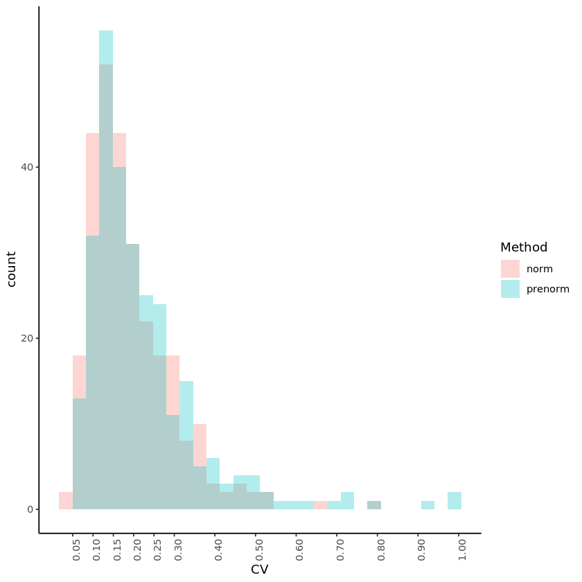

```r
hist_CV_EC
```

```r
hist_CV_EC_post <- ggplot(data=subset(CV_ECs,Method=="norm"),aes(x=CV,fill=Method))+
geom_histogram(position = "identity",alpha=0.3,)+
theme_classic()+
scale_x_continuous(breaks=c(0.05,0.1,0.15,0.2,0.25,0.3,0.4,0.5,0.6,0.7,0.8,0.9,1))+
theme(axis.text.x = element_text(angle = 90),
legend.position="none")+
xlab("RSD (%)")
```

**CV in EC samples after normalization**

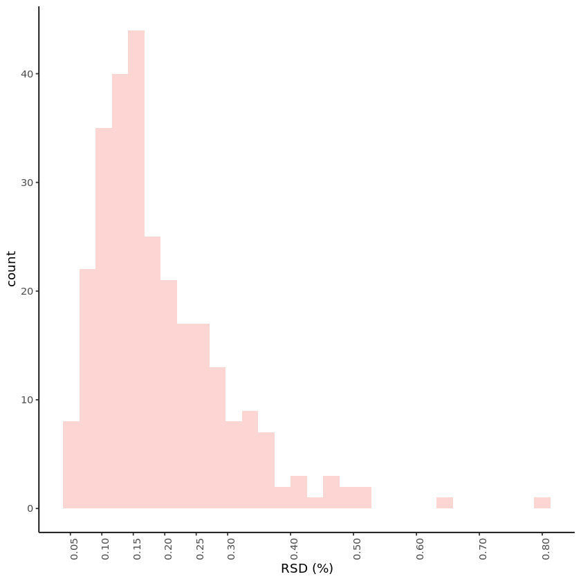

```r
hist_CV_EC_post
```

```r
ggsave(".../Figure_S6.pdf",hist_CV_EC_post)
```

# Calculate CV in Pools

```r
Pools <- subset(ft_norm,class=="Pool")[,-c(1:4)]
Pools[Pools<1] <-0
Pools <- Pools[colSums(Pools==0)==0]
Pools_prenorm <- subset(ft,class=="Pool")[,-c(1:4)]
Pools_prenorm <- Pools_prenorm[names(Pools_prenorm) %in% names(Pools)]
Pools_prenorm <- apply(Pools_prenorm,2,function(n){as.numeric(as.character(n))})
```

```r
dim(Pools)
dim(Pools_prenorm)
```

1. 76

2. 363

1. 76

2. 363

```r
CV_norm_pools <- sapply(1:ncol(Pools),function(n){(sd(Pools[,n])/mean(Pools[,n]))})
CV_norm_pools[is.na(CV_norm_pools)] <- 1
CV_pools_prenorm <- sapply(1:ncol(Pools_prenorm),function(n){(sd(Pools_prenorm[,n])/mean(Pools_prenorm[,n]))})
```

```r
sum(CV_norm_pools<0.3,na.rm=TRUE)
sum(CV_pools_prenorm<0.3,na.rm = TRUE)
```

343

307

```r
CV_pools_prenorm[is.na(CV_pools_prenorm)] <- 1
CV_pools <- cbind.data.frame(rep(names(Pools),2),c(CV_norm_pools,CV_pools_prenorm),
                           c(rep("norm",length(CV_norm_pools)),rep("prenorm",length(CV_pools_prenorm))))

colnames(CV_pools) <- c("Metabolites","CV","Method")
CV_pools$CV[CV_pools$CV>1] <- 1
```

```r
hist_CV_Pools <- ggplot(data=CV_pools,aes(x=CV,fill=Method))+
geom_histogram(position = "identity",alpha=0.3,)+
theme_classic()+
scale_x_continuous(breaks=c(0.05,0.1,0.15,0.2,0.25,0.3,0.4,0.5,0.6,0.7,0.8,0.9,1))+
theme(axis.text.x = element_text(angle = 90))
```

**Show CV in pooled samples before and after batch correction**

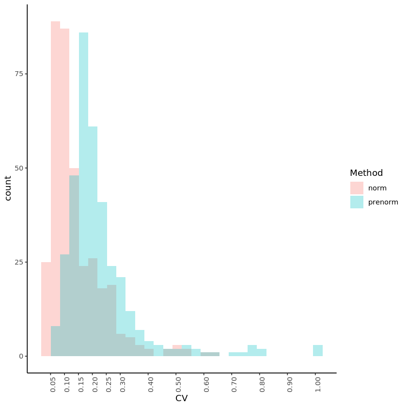

```r
hist_CV_Pools
```

# Evaluate using PCA

```r
PCA_norm <- prcomp(x=ft_norm[,-c(1:4)],scale=TRUE,center = TRUE)
```

```r
PCA_plot <- cbind.data.frame(ft_norm$class,ft_norm$batch,PCA_norm$x[,1],PCA_norm$x[,2],PCA_norm$x[,3])
colnames(PCA_plot) <- c("class","batch","PC1","PC2","PC3")
```

```r
PCA_plot <- subset(PCA_plot,class!="EC")
```

```r
pca_batches <- ggplot(PCA_plot,aes(x=PC1,y=PC3,color=batch))+
geom_point()+
theme_minimal()
```

```r
ggsave(".../Figure_S7.pdf",pca_batches)
```

# Export batch corrected data

```r
write.csv(ft_norm_out,".../ft_blankfilled_normalized_continuous.csv")
```